# likelihood

Yunfeng Yang

6/28/2022

In order to address the discontinuity in the plot, we propose a new linear model:

$$Y^* = Y\cdot I(cY>l || Y <l) + (1/\alpha\cdot Y + l/c -
1/\alpha\cdot l/c)\cdot I(l<Y<l/c)$$

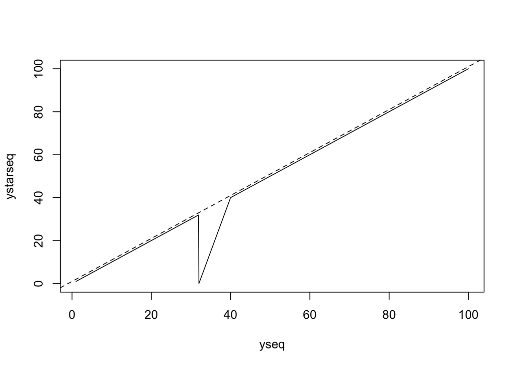

```r
yseq <- seq(from = 1, to = 100, by =.1)
ystarseq <- ((1/0.2)*yseq + 32/.8 - 1/0.2*32/.8)*ifelse(.8*yseq<32 & yseq > 32,1,0) + yseq*ifelse(.8*yseq>=32 | yseq < 32,1,0)

plot(yseq,ystarseq, type = 'l', ylim =c(0,100))
# the dash line is no damaged plot
abline(yseq, yseq, lty = 2)
```

The solid line (damaged pieces) is below the dash line (undamaged pieces), which is what we want.

# Likelihood derivation

## The likelihood of the pieces surviving after the proof loading, group 3

Below we derive the likelihood of pieces surviving after the proof loading, which may be damaged or damaged according to the threshold. The group will be referred to group 3 later.

Given the model $Y^* = Y \cdot I(cY>l) + (1/\alpha \cdot Y + l/c - 1/\alpha \cdot l/c) \cdot I(cY<l)$, we can obtain

$$\begin{equation}
\begin{split}
p(Y^* < y^* ) &= p(Y < y^*|cY>l )p(cY>l) +
p(\frac{1}{\alpha} \cdot Y + \frac{l}{c} - \frac{1}{\alpha} \cdot
\frac{l}{c}) <y^* | cY<l)p(cY<l) \\
&= p(Y < y^*, Y > \frac{l}{c}) + p(Y < \alpha \cdot y^* +
\frac{l}{c} - \frac{\alpha\cdot l}{c}, Y <\frac{l}{c} )
\end{split}
\end{equation}$$

Hence
$$\begin{equation}
\begin{aligned}
p(Y^* < y^* ) =
\begin{cases}
p(Y < \alpha \cdot y^* + l/c - \alpha \cdot l/c) & y^* < l/c
\\
p(Y < y^*) & y^* > l/c.
\end{cases}
\end{aligned}
\end{equation}$$

And we can obtain the pdf:
$$\begin{equation}
\begin{aligned}
f_{Y^*}( y^* ) =
\begin{cases}
\alpha \cdot f_{Y}(\alpha y^* + l/c - \alpha\cdot l/c) & y^* <
l/c \\
f_{Y}(y^*) & y^* > l/c.
\end{cases}
\end{aligned}
\end{equation}$$
where $f_{Y}$ is the pdf of normal distribution.

### The likelihood of the coding

When $y^* > l/c$, $p(Y^* < y^*\mid Y^* >l/c) = p(Y < y^* \mid Y>l/c) = p(Y<y^*, Y>l/c)/p(Y>l/c)$

So when $y^* > l/c$, $f_{Y^*}(y^*) = f_{Y}(y^*)/p(Y>l/c)$.

when $l <y^* < l/c$,

$p(Y^* < y^*\mid l<Y^* <l/c) = p(\frac{1}{\alpha} \cdot Y + \frac{l}{c} - \frac{1}{\alpha} \cdot \frac{l}{c} < y^* \mid l<\frac{1}{\alpha} \cdot Y + \frac{l}{c} - \frac{1}{\alpha} \cdot \frac{l}{c}<l/c) = p(Y <\alpha \cdot y^* + l/c - \alpha \cdot l/c, \alpha \cdot l + l/c - \alpha \cdot l/c< Y <l/c)/p(Y\alpha \cdot l + l/c - \alpha \cdot l/c< Y <l/c) = p(Y <\alpha \cdot y^* + l/c - \alpha \cdot l/c)/p(\alpha \cdot l + l/c - \alpha \cdot l/c< Y <l/c)$

$$\begin{equation}
\begin{aligned}
p(Y^* < y^*\mid l<Y^* <l/c) &= p(\frac{1}{\alpha} \cdot Y +
\frac{l}{c} - \frac{1}{\alpha} \cdot \frac{l}{c} < y^* \mid
l<\frac{1}{\alpha} \cdot Y + \frac{l}{c} - \frac{1}{\alpha} \cdot
\frac{l}{c}<l/c) \\
&= p(Y <\alpha \cdot y^* + l/c - \alpha \cdot l/c, \alpha \cdot l
+ l/c - \alpha \cdot l/c< Y <l/c)/p(Y\alpha \cdot l + l/c - \alpha
\cdot l/c< Y <l/c) \\
&= p(Y <\alpha \cdot y^* + l/c - \alpha \cdot l/c)/p(\alpha \cdot
l + l/c - \alpha \cdot l/c< Y <l/c)\\
\end{aligned}
\end{equation}$$

When $l <y^* < l/c$, $f_{Y^*}(y^*) = p(Y <\alpha \cdot y^* + l/c - \alpha \cdot l/c)/p(Y\alpha \cdot l + l/c - \alpha \cdot l/c< Y <l/c)$.

## The likelihood of the pieces of being broken after the proof loading, group 2

Below we derive the likelihood of the pieces of being broken after the proof loading. The group will be referred to group 2 later.

It indicates the model $Y > l$ and $Y^* < l$.

The latter is converted due to below:

$$\begin{equation}
\begin{aligned}
Y^* &< l \\
Y \cdot I(cY>l) + (1/\alpha \cdot Y + l/c - 1/\alpha \cdot l/c) \cdot
I(cY<l) &< l \\
\end{aligned}
\end{equation}$$

If $Y > l/c$, it becomes $Y <l$. However as $l/c > l$ always holds, this case is impossible.

If $Y < l/c$, it becomes $1/\alpha \cdot Y + l/c - 1/\alpha \cdot l/c < l$. Then it is $Y < \alpha \cdot l + l/c - \alpha \cdot l/c$.

Suppose there are $n$ pieces in this group 2, the likelihood of the group is $p(l<Y<\alpha \cdot l + l/c - \alpha \cdot l/c)^n$.

# The likelihood for each piece

Let $f_{Y}(y;\mu,\sigma^2)$ denote the normal pdf at a given value $y$ with mean $\mu$ and variance $\sigma^2$.

- When $y<l$, it belongs to group 1 where pieces are broken under the proof loading level. The likelihood for each piece is $f_{Y}(y;\mu,\sigma^2)$. Note that the group 1 is not under any proof loading damage effect, so the likelihood is not associated with $y^*$
- When $\frac{l}{\alpha} + \frac{l}{c} - \frac{1}{\alpha}\cdot\frac{l}{c}<y^*<l$ or $l<y<\alpha \cdot l + l/c - \alpha \cdot l/c$ (basically it is derived from $y>l$ and $y^*<l$), the group 2 refers to the pieces which survived initially but broken after the damaged effect. The likelihood for each piece is $f_{y^*}(y^*) = p(l<Y<\alpha \cdot l + l/c - \alpha \cdot l/c)$, where $Y$ follows $N(\mu, \sigma^2)$.
- When $l<y^*<l/c$, it refers to group 3 where pieces survive after the proof loading level but are damaged/weaken. The likelihood for each piece is $f_{Y^*}(y^*) = \alpha \cdot f_{Y}(\alpha y^* + l/c - \alpha\cdot l/c;\mu,\sigma^2)$.
- When $y^*>l/c$, it refers to group 3 where pieces survive after the proof loading level and no damage effect occurs. The likelihood for each piece is $f_{Y^*}(y^*) = f_{Y}(y^*;\mu,\sigma^2)$.

To summarize, in group 1, the likelihood for each piece is $f_{Y}(y;\mu,\sigma^2)$.

In group 2 and group 3, the likelihood for each piece is

$$\begin{equation}
\begin{aligned}
f_{Y^*}( y^* ) =
\begin{cases}
p(l<Y<\alpha \cdot l + l/c - \alpha \cdot l/c) &
\frac{l}{\alpha} + \frac{l}{c} -
\frac{1}{\alpha}\cdot\frac{l}{c}<y^*<l\\
\alpha \cdot f_{Y}(\alpha y^* + l/c - \alpha\cdot l/c;\mu,\sigma^2)
& l<y^*<l/c \\
f_{Y}(y^* ;\mu,\sigma^2) & y^* > l/c.
\end{cases}
\end{aligned}
\end{equation}$$

# Questions

1. The pieces in group 1 and group 2 can have the same ystar, i.e., the damage model is not a one-to-one function in these two groups. How would you explain that?

It is possible. One piece in group 2 can be stronger than another one in group 1. But then the former in group 2 is damaged/weaken to be the same strong as the latter in group 1.

2. Another likelihood for group 3

$$\begin{aligned}
&p(Y^* < y^* \mid Y^* > l) \\
= & p (Y\cdot I(cY>l) + (1/\alpha\cdot Y + l/c - 1/\alpha\cdot
l/c)\cdot I(l<Y<l/c) \mid Y^* > l) \\
= & p(Y < y^* \mid Y^* >l,Y > l/c)p(Y>l/c) +
p(1/\alpha\cdot Y + l/c - 1/\alpha\cdot l/c < y^* \mid Y^* > l,
l<Y<l/c)p(l<Y<l/c) \\
=& p(Y < y^* \mid Y > l/c)p(Y>l/c) + p(1/\alpha\cdot Y +
l/c - 1/\alpha\cdot l/c < y^* \mid \alpha l + l/c - \alpha
l/c<Y<l/c)p(l<Y<l/c) \\
=& p(l/c <Y < y^* ) + p(Y<\alpha Y^* + l/c - \alpha l/c,
\alpha l + l/c - \alpha l/c<Y<l/c )p(\alpha l + l/c - \alpha
l/c<Y<l/c )/p(l>Y<l/c)
\end{aligned}$$

So when $y^*> l/c$, $f_{Y^*}(y^*) = f_{Y}(y^*)$.

When $l<y^*<l/c$, $f_{Y^*}(y^*) = \alpha f_{Y}(\alpha Y^* + l/c - \alpha l/c)p(\alpha l + l/c - \alpha l/c<Y<l/c )/p(l>Y<l/c)$.

# CDF and PDf of ystar

Use `density()` and `ecdf()`

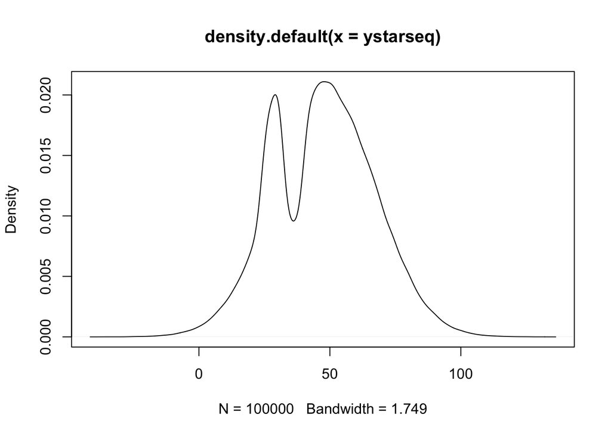

```r
yseq <- rnorm(100000,mean = 48, sd = 19)
ystarseq <- ((1/0.5)*yseq + 32/.8 - 1/0.5*32/.8)*ifelse(.8*yseq<32 & yseq > 32,1,0) + yseq*ifelse(.8*yseq>=32 | yseq < 32,1,0)
plot(density(ystarseq))
```

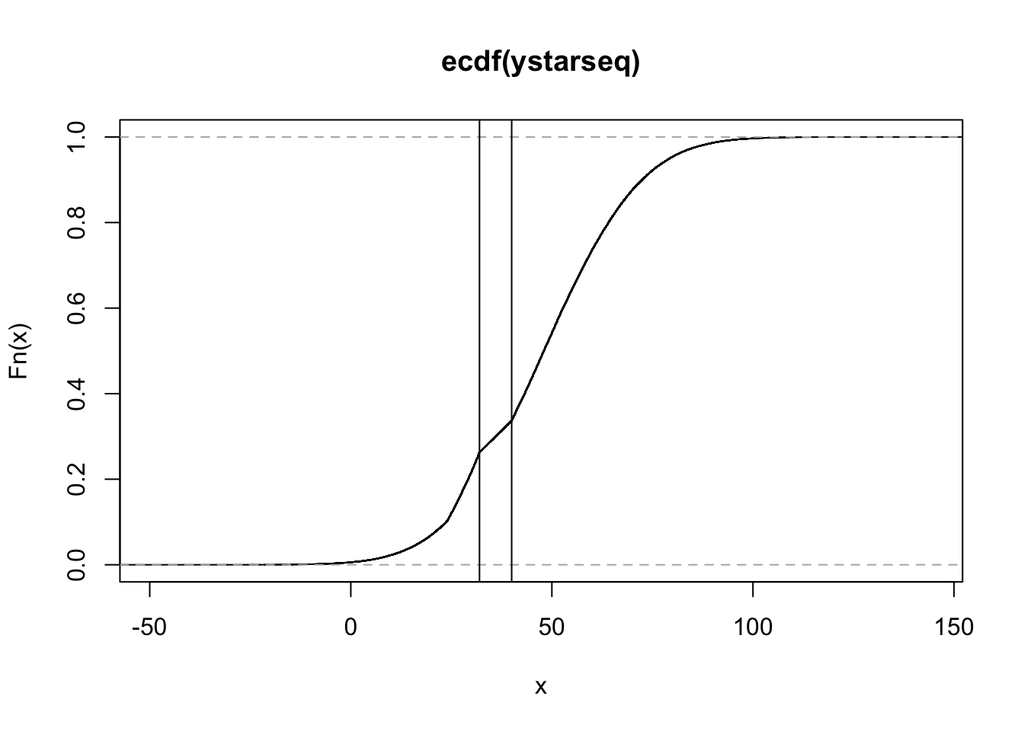

```r
plot(ecdf(ystarseq))
abline(v = 32)
abline(v = 32/.8)
```

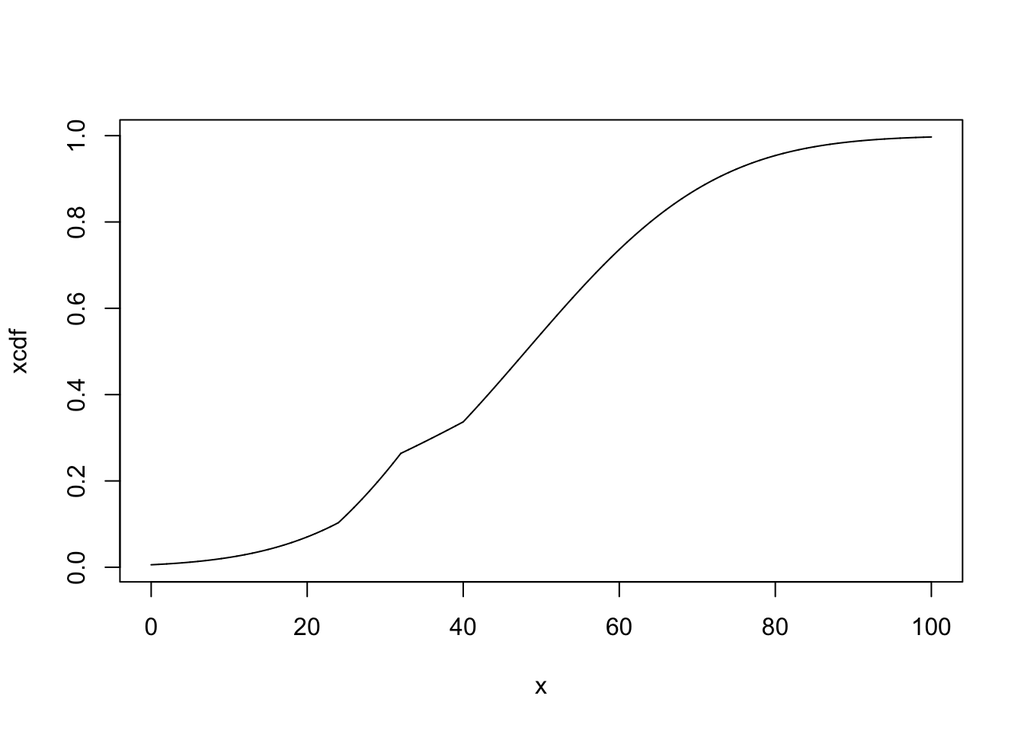

```r
x <- seq(from = 0, to = 100, by = .01)

alpha <- .5
c <- .8
l <- 32
xcdf <- c()
for(ii in 1:length(x)){
  if(x[ii] < 1/alpha*l + l/c - 1/alpha*l/c){
    xcdf[ii] <- pnorm(x[ii], mean = 48, sd = 19)
  }
  else if(x[ii] > 1/alpha*l + l/c - 1/alpha*l/c & x[ii] <l){
    xcdf[ii] <- pnorm(x[ii], mean = 48, sd = 19) +
      pnorm(alpha*x[ii] + l/c - alpha*l/c, mean = 48, sd = 19) -
      pnorm(l, mean = 48, sd = 19)
  }
  else if(x[ii] > l & x[ii] < l/c){
    xcdf[ii] <- pnorm(alpha*x[ii] + l/c - alpha*l/c, mean = 48, sd = 19)
  }
  else if(x[ii] > l/c){
    xcdf[ii] <- pnorm(x[ii], mean = 48, sd = 19)
  }

}

plot(x,xcdf,type = 'l')
```

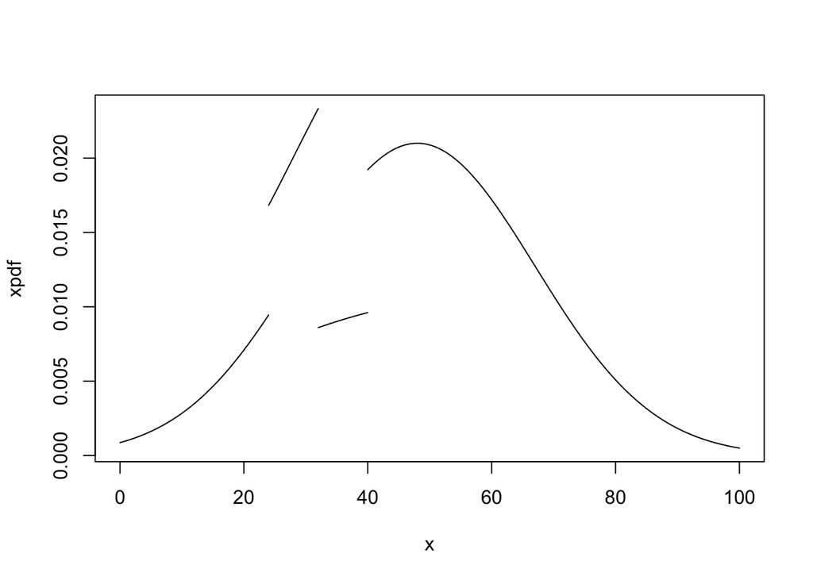

```r
## pdf
xpdf <- c()
for(ii in 1:length(x)){
  if(x[ii] < 1/alpha*l + l/c - 1/alpha*l/c){
    xpdf[ii] <- dnorm(x[ii], mean = 48, sd = 19)
  }
  else if(x[ii] > 1/alpha*l + l/c - 1/alpha*l/c & x[ii] <l){
    xpdf[ii] <- dnorm(x[ii], mean = 48, sd = 19) +
      alpha*dnorm(alpha*x[ii] + l/c - alpha*l/c, mean = 48, sd = 19)
  }
  else if(x[ii] > l & x[ii] < l/c){
    xpdf[ii] <- alpha*dnorm(alpha*x[ii] + l/c - alpha*l/c, mean = 48, sd = 19)
  }
  else if(x[ii] > l/c){
    xpdf[ii] <- dnorm(x[ii], mean = 48, sd = 19)
  }

}
plot(x,xpdf,type = 'l')
```

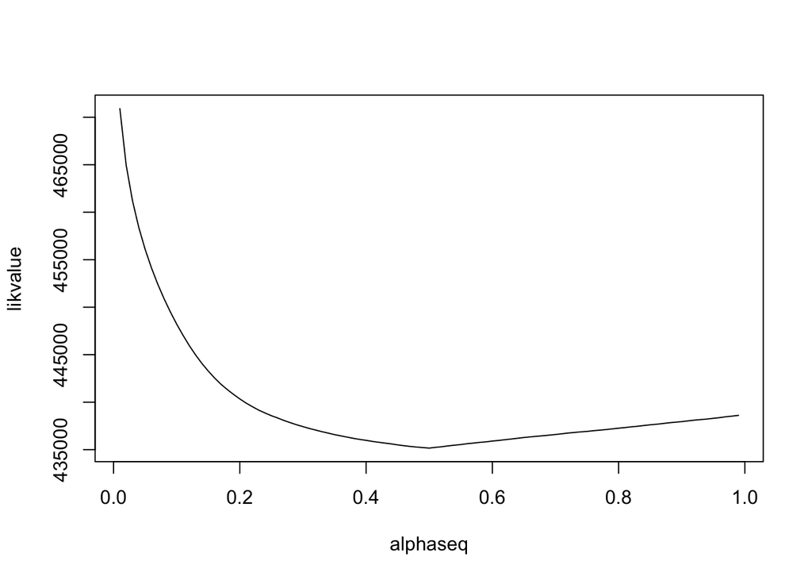

```r
dmglik <- function(x, alpha){
  mu <- 48
  sigma <- 19
  lik <- 0

  id1 <-  x < 1/alpha*l + l/c - 1/alpha*l/c
  lik <- sum(dnorm(x[id1], mean = mu, sd = sigma, log = TRUE))

  id2 <- x> 1/alpha*l + l/c - 1/alpha*l/c & x <l
  lik <- lik + sum(log(dnorm(x[id2], mean = mu, sd = sigma) +
    alpha*dnorm(alpha*x[id2] + l/c - alpha*l/c, mean = mu, sd = sigma)))

  id3 <- x > l & x < l/c
  lik <- lik + sum(log(alpha*dnorm(alpha*x[id3] + l/c - alpha*l/c, mean = mu, sd = sigma)))

  id4 <- x > l/c
  lik <- lik + sum(dnorm(x[id4], mean = mu, sd = sigma, log = TRUE))

  return(-lik)

}


alphaseq <- seq(from = .01, to = .99, by = 0.01)
likvalue <- c()
for (jj in 1:length(alphaseq)){
  likvalue[jj] <- dmglik(ystarseq, alphaseq[jj])
}

plot(alphaseq, likvalue, type = 'l')
```

```r
dmglik <- function(x, theta){
  mu <- theta[1]
  sigma <- theta[2]
  alpha <- theta[3]
  c <- theta[4]
  lik <- 0

  id1 <-  x < 1/alpha*l + l/c - 1/alpha*l/c
  lik <- sum(dnorm(x[id1], mean = mu, sd = sigma, log = TRUE))

  id2 <- x> 1/alpha*l + l/c - 1/alpha*l/c & x <l
  lik <- lik + sum(log(dnorm(x[id2], mean = mu, sd = sigma) +
                         alpha*dnorm(alpha*x[id2] + l/c - alpha*l/c, mean = mu, sd = sigma)))

  id3 <- x > l & x < l/c
  lik <- lik + sum(log(alpha*dnorm(alpha*x[id3] + l/c - alpha*l/c, mean = mu, sd = sigma)))

  id4 <- x > l/c
  lik <- lik + sum(dnorm(x[id4], mean = mu, sd = sigma, log = TRUE))

  return(-lik)

}

optim(c(48,19,.5,.5),dmglik, x = ystarseq,
      lower = c(20,10,.001,.001),
      upper = c(80,30,2,2),
      method = "L-BFGS-B")$par
```

```
## [1] 48.0537329 18.9925376  0.4999756  0.8000408
```